# Developing an AI application

Going forward, AI algorithms will be incorporated into more and more everyday applications. For example, you might want to include an image classifier in a smart phone app. To do this, you'd use a deep learning model trained on hundreds of thousands of images as part of the overall application architecture. A large part of software development in the future will be using these types of models as common parts of applications.

In this project, you'll train an image classifier to recognize different species of flowers. You can imagine using something like this in a phone app that tells you the name of the flower your camera is looking at. In practice you'd train this classifier, then export it for use in your application. We'll be using [this dataset](http://www.robots.ox.ac.uk/~vgg/data/flowers/102/index.html) of 102 flower categories, you can see a few examples below.

[figure not shown]

The project is broken down into multiple steps:

- Load and preprocess the image dataset
- Train the image classifier on your dataset
- Use the trained classifier to predict image content

We'll lead you through each part which you'll implement in Python.

When you've completed this project, you'll have an application that can be trained on any set of labeled images. Here your network will be learning about flowers and end up as a command line application. But, what you do with your new skills depends on your imagination and effort in building a dataset. For example, imagine an app where you take a picture of a car, it tells you what the make and model is, then looks up information about it. Go build your own dataset and make something new.

First up is importing the packages you'll need. It's good practice to keep all the imports at the beginning of your code. As you work through this notebook and find you need to import a package, make sure to add the import up here.

```python
# Download the dataset
# This cell has to run only once.
# NO need to run every time you arrive on this notebook.

import requests
import tarfile
import os
import shutil

# Define the URL and folder paths
url = "https://s3.amazonaws.com/content.udacity-data.com/nd089/flower_data.tar.gz"
folder_name = "flowers"
file_name = "flower_data.tar.gz"
file_path = os.path.join(folder_name, file_name)

# Remove the folder or symbolic link if it already exists (equivalent to `rm -rf flowers`)
try:
    if os.path.islink(folder_name) or os.path.isfile(folder_name):
        os.remove(folder_name)  # Remove the symbolic link or file
    elif os.path.isdir(folder_name):
        shutil.rmtree(folder_name)  # Remove the directory
    print(f"Removed existing {folder_name} folder/file/soft link, if any.")
except FileNotFoundError:
    pass  # If the file or directory does not exist, do nothing

# Create the folder
os.makedirs(folder_name)
print(f"Created folder: {folder_name}")

# Download the file
response = requests.get(url, stream=True)

# Save the file in the 'flowers' folder
with open(file_path, "wb") as file:
    for chunk in response.iter_content(chunk_size=1024):
        if chunk:
            file.write(chunk)

print(f"Downloaded {file_name} to {folder_name}")

# Extract the file in the 'flowers' folder
if file_path.endswith("tar.gz"):
    with tarfile.open(file_path, "r:gz") as tar:
        tar.extractall(path=folder_name)
        print(f"Extracted {file_name} to {folder_name}")

# Clean up by removing the tar.gz file after extraction
os.remove(file_path)
print(f"Removed the downloaded tar.gz file: {file_path}")
```

```
Removed existing flowers folder/file/soft link, if any.
Created folder: flowers
Downloaded flower_data.tar.gz to flowers
```

```
Extracted flower_data.tar.gz to flowers
Removed the downloaded tar.gz file: flowers/flower_data.tar.gz
```

```python
# Imports
import torch
import torchvision
from torch import nn, optim
from torchvision import transforms
from torchvision.datasets import ImageFolder
from torch.utils.data import DataLoader
from PIL import Image
import matplotlib
import numpy as np
import os
from train import engine
from typing import Dict, List, Tuple
import matplotlib.pyplot as plt
import importlib
from typing import Dict, List, Tuple
%matplotlib inline
```

```python
# Setup device agnostic code
device = "cuda" if torch.cuda.is_available() else "cpu"
device
```

```
'cpu'
```

## Load the data

Here you'll use `torchvision` to load the data ([documentation](http://pytorch.org/docs/0.3.0/torchvision/index.html)). The data should be included alongside this notebook, otherwise you can [download it here](https://s3.amazonaws.com/content.udacity-data.com/nd089/flower_data.tar.gz). The dataset is split into three parts, training, validation, and testing. For the training, you'll want to apply transformations such as random scaling, cropping, and flipping. This will help the network generalize leading to better performance. You'll also need to make sure the input data is resized to 224x224 pixels as required by the pre-trained networks.

The validation and testing sets are used to measure the model's performance on data it hasn't seen yet. For this you don't want any scaling or rotation transformations, but you'll need to resize then crop the images to the appropriate size.

The pre-trained networks you'll use were trained on the ImageNet dataset where each color channel was normalized separately. For all three sets you'll need to normalize the means and standard deviations of the images to what the network expects. For the means, it's `[0.485, 0.456, 0.406]` and for the standard deviations `[0.229, 0.224, 0.225]`, calculated from the ImageNet images. These values will shift each color channel to be centered at 0 and range from -1 to 1.

```python
data_dir = 'flowers'
train_dir = data_dir + '/train'
valid_dir = data_dir + '/valid'
test_dir = data_dir + '/test'
```

```python
# Define your transforms for the training, validation, and testing sets
data_transforms = {
    'train': transforms.Compose([
        transforms.RandomRotation(30),
        transforms.RandomResizedCrop(224),
        transforms.RandomHorizontalFlip(),
        transforms.ToTensor(),
        transforms.Normalize([0.485, 0.456, 0.406],
                           [0.229, 0.224, 0.225])
    ]),
    'valid': transforms.Compose([
        transforms.Resize(256),
        transforms.CenterCrop(224),
        transforms.ToTensor(),
        transforms.Normalize([0.485, 0.456, 0.406],
                           [0.229, 0.224, 0.225])
    ]),
    'test': transforms.Compose([
        transforms.Resize(256),
        transforms.CenterCrop(224),
        transforms.ToTensor(),
        transforms.Normalize([0.485, 0.456, 0.406],
                           [0.229, 0.224, 0.225])
    ])
}

# Load the datasets with ImageFolder
image_datasets = {
    'train': ImageFolder(train_dir, transform=data_transforms['train']),
    'valid': ImageFolder(valid_dir, transform=data_transforms['valid']),
    'test': ImageFolder(test_dir, transform=data_transforms['test'])
}

# Using the image datasets and the trainforms, define the dataloaders
dataloaders = {
    'train': DataLoader(image_datasets['train'], batch_size=64, shuffle=True),
    'valid': DataLoader(image_datasets['valid'], batch_size=32, shuffle=False),
    'test': DataLoader(image_datasets['test'], batch_size=32, shuffle=False)
}
```

```python
# Checking the dataset size
dataset_sizes = {x: len(image_datasets[x]) for x in ['train', 'valid', 'test']}
class_names = image_datasets['train'].classes

# Print dataset information
print("\nDataset Information:")
print(f"Number of training images: {dataset_sizes['train']}")
print(f"Number of validation images: {dataset_sizes['valid']}")
print(f"Number of test images: {dataset_sizes['test']}")
print(f"Number of classes: {len(class_names)}")
print(f"Classes: {class_names}")
```

```
Dataset Information:
Number of training images: 6552
Number of validation images: 818
Number of test images: 820
Number of classes: 102
Classes: ['1', '10', '100', '101', '102', '11', '12', '13', '14', '15', '16', '17', '18', '19', '2', '20', '21', '22', '23', '24', '25', '26', '27', '28', '29', '3', '30', '31', '32', '33', '34', '35', '36', '37', '38', '39', '4', '40', '41', '42', '43', '44', '45', '46', '47', '48', '49', '5', '50'…
```

### Label mapping

You'll also need to load in a mapping from category label to category name. You can find this in the file `cat_to_name.json`. It's a JSON object which you can read in with the [`json` module](https://docs.python.org/2/library/json.html). This will give you a dictionary mapping the integer encoded categories to the actual names of the flowers.

```python
import json

with open('cat_to_name.json', 'r') as f:
    cat_to_name = json.load(f)
```

# Building and training the classifier

Now that the data is ready, it's time to build and train the classifier. As usual, you should use one of the pretrained models from `torchvision.models` to get the image features. Build and train a new feed-forward classifier using those features.

We're going to leave this part up to you. Refer to [the rubric](https://review.udacity.com/#!/rubrics/1663/view) for guidance on successfully completing this section. Things you'll need to do:

- Load a [pre-trained network](http://pytorch.org/docs/master/torchvision/models.html) (If you need a starting point, the VGG networks work great and are straightforward to use)
- Define a new, untrained feed-forward network as a classifier, using ReLU activations and dropout
- Train the classifier layers using backpropagation using the pre-trained network to get the features
- Track the loss and accuracy on the validation set to determine the best hyperparameters

We've left a cell open for you below, but use as many as you need. Our advice is to break the problem up into smaller parts you can run separately. Check that each part is doing what you expect, then move on to the next. You'll likely find that as you work through each part, you'll need to go back and modify your previous code. This is totally normal!

When training make sure you're updating only the weights of the feed-forward network. You should be able to get the validation accuracy above 70% if you build everything right. Make sure to try different hyperparameters (learning rate, units in the classifier, epochs, etc) to find the best model. Save those hyperparameters to use as default values in the next part of the project.

One last important tip if you're using the workspace to run your code: To avoid having your workspace disconnect during the long-running tasks in this notebook, please read in the earlier page in this lesson called Intro to GPU Workspaces about Keeping Your Session Active. You'll want to include code from the workspace_utils.py module.

**Note for Workspace users:** If your network is over 1 GB when saved as a checkpoint, there might be issues with saving backups in your workspace. Typically this happens with wide dense layers after the convolutional layers. If your saved checkpoint is larger than 1 GB (you can open a terminal and check with `ls -lh`), you should reduce the size of your hidden layers and train again.

```python
# Load the pretrained model: the DEFAULT will choose the best available weights for model
weights = torchvision.models.EfficientNet_B0_Weights.DEFAULT
model = torchvision.models.efficientnet_b0(weights=weights).to(device)

# Check the classifier structure of the original model because understanding this will help us
# to well structure the new one
print("Original Classifier:")
print(model.classifier)
print("\n")
```

```
Original Classifier:
Sequential(
  (0): Dropout(p=0.2, inplace=True)
  (1): Linear(in_features=1280, out_features=1000, bias=True)
)
```

```python
# Freeze all base layers in the "features" section of the model (the feature extractor) by setting requires_grad=False
for param in model.features.parameters():
    param.requires_grad = False
```

```python
# Define number of classes from our dataset
output_shape = len(cat_to_name)
print(f"Number of classes: {output_shape}")
```

```
Number of classes: 102
```

```python
# Recreate the classifier layer and seed it to the target device
model.classifier = torch.nn.Sequential(
    torch.nn.Dropout(p=0.2, inplace=True),
    torch.nn.Linear(in_features=1280,
                    out_features=output_shape, # same number of output units as our number of classes
                    bias=True)).to(device)
```

```python
# Check the classifier structure of the original model because understanding this will help us to well structure the new one
print("New Classifier:")
print(model.classifier)
print("\n")
```

```
New Classifier:
Sequential(
  (0): Dropout(p=0.2, inplace=True)
  (1): Linear(in_features=1280, out_features=102, bias=True)
)
```

```python
# Setup hyperparameters
NUM_EPOCHS = 5
LEARNING_RATE = 0.001

# Define loss and optimizer
loss_fn = nn.CrossEntropyLoss()
optimizer = torch.optim.Adam(model.parameters(), lr=LEARNING_RATE)
```

```python
# Training the model
def train_step(model: torch.nn.Module,
               dataloader: torch.utils.data.DataLoader,
               loss_fn: torch.nn.Module,
               optimizer: torch.optim.Optimizer,
               device: torch.device) -> Tuple[float, float]:

    # Put model in train mode
    model.train()

    # Setup train loss and train accuracy values
    train_loss, train_acc = 0, 0

    # Loop through data loader data batches
    for batch, (X, y) in enumerate(dataloader):
        # Send data to target device
        X, y = X.to(device), y.to(device)

        # Forward pass
        y_pred = model(X)

        # Calculate  and accumulate loss
        loss = loss_fn(y_pred, y)
        train_loss += loss.item()

        # Optimizer zero grad
        optimizer.zero_grad()

        # Loss backward
        loss.backward()

        # Optimizer step
        optimizer.step()

        # Calculate and accumulate accuracy metric across all batches
        y_pred_class = torch.argmax(torch.softmax(y_pred, dim=1), dim=1)
        train_acc += (y_pred_class == y).sum().item()/len(y_pred)

    # Adjust metrics to get average loss and accuracy per batch
    train_loss = train_loss / len(dataloader)
    train_acc = train_acc / len(dataloader)
    return train_loss, train_acc

def test_step(model: torch.nn.Module,
              dataloader: torch.utils.data.dataloader.DataLoader,
              loss_fn: torch.nn.Module,
              device: torch.device) -> Tuple[float, float]:

    # Put model in eval mode
    model.eval()

    # Setup test loss and test accuracy values
    test_loss, test_acc = 0, 0

    # Turn on inference context manager
    with torch.inference_mode():
        # Loop through DataLoader batches
        for batch, (X, y) in enumerate(dataloader):
            # Send data to target device
            X, y = X.to(device), y.to(device)

            # Forward pass
            test_pred_logits = model(X)

            # Calculate and accumulate loss
            loss = loss_fn(test_pred_logits, y)
            test_loss += loss.item()

            # Calculate and accumulate accuracy
            test_pred_labels = test_pred_logits.argmax(dim=1)
            test_acc += ((test_pred_labels == y).sum().item()/len(test_pred_labels))

    # Adjust metrics to get average loss and accuracy per batch
    test_loss = test_loss / len(dataloader)
    test_acc = test_acc / len(dataloader)
    return test_loss, test_acc

# The engine will be call to run the test
def engine(model: torch.nn.Module,
          train_dataloader: torch.utils.data.DataLoader,
          test_dataloader: torch.utils.data.DataLoader,
          optimizer: torch.optim.Optimizer,
          loss_fn: torch.nn.Module,
          epochs: int,
          device: torch.device) -> Dict[str, List]:

    # Create empty results dictionary to keepall the data
    results = {"train_loss": [],
               "train_acc": [],
               "test_loss": [],
               "test_acc": []
    }

    # Make sure model on target device
    model.to(device)

    # Loop through training and testing steps for a number of epochs
    print("Starting training...")
    for epoch in range(epochs):
        print(f"\nEpoch {epoch+1}/{epochs}")
        train_loss, train_acc = train_step(model=model,
                                          dataloader=train_dataloader,
                                          loss_fn=loss_fn,
                                          optimizer=optimizer,
                                          device=device)
        test_loss, test_acc = test_step(
                                      model=model,
                                      dataloader=test_dataloader,
                                      loss_fn=loss_fn,
                                      device=device)

        # Print out what's happening
        print(
          f"Epoch: {epoch+1} | "
          f"train_loss: {train_loss:.4f} | "
          f"train_acc: {train_acc:.4f} | "
          f"test_loss: {test_loss:.4f} | "
          f"test_acc: {test_acc:.4f}"
        )

        # Update results dictionary
        results["train_loss"].append(train_loss)
        results["train_acc"].append(train_acc)
        results["test_loss"].append(test_loss)
        results["test_acc"].append(test_acc)

    # Return the filled results at the end of the epochs
    return results
```

```python
# Training the model
torch.manual_seed(42)
torch.cuda.manual_seed(42)

# Start the timer
from timeit import default_timer as timer
start_time = timer()

# Setup training
results = engine(model=model,
                       train_dataloader=dataloaders['train'],
                       test_dataloader=dataloaders['valid'],
                       optimizer=optimizer,
                       loss_fn=loss_fn,
                       epochs=NUM_EPOCHS,
                       device=device)

# End the timer and print out how long it took
end_time = timer()
print(f"[INFO] Total training time: {end_time-start_time:.3f} seconds")
```

[output not shown]

```python
# Plot loss curves of a model
def plot_loss_curves(results):

    loss = results["train_loss"]
    test_loss = results["test_loss"]

    accuracy = results["train_acc"]
    test_accuracy = results["test_acc"]
    epochs = range(len(results["train_loss"]))

    plt.figure(figsize=(15, 7))

    # Plot loss
    plt.subplot(1, 2, 1)
    plt.plot(epochs, loss, label="train_loss")
    plt.plot(epochs, test_loss, label="test_loss")
    plt.title("Loss")
    plt.xlabel("Epochs")
    plt.legend()

    # Plot accuracy
    plt.subplot(1, 2, 2)
    plt.plot(epochs, accuracy, label="train_accuracy")
    plt.plot(epochs, test_accuracy, label="test_accuracy")
    plt.title("Accuracy")
    plt.xlabel("Epochs")
    plt.legend()

    plt.tight_layout()
    plt.show()
```

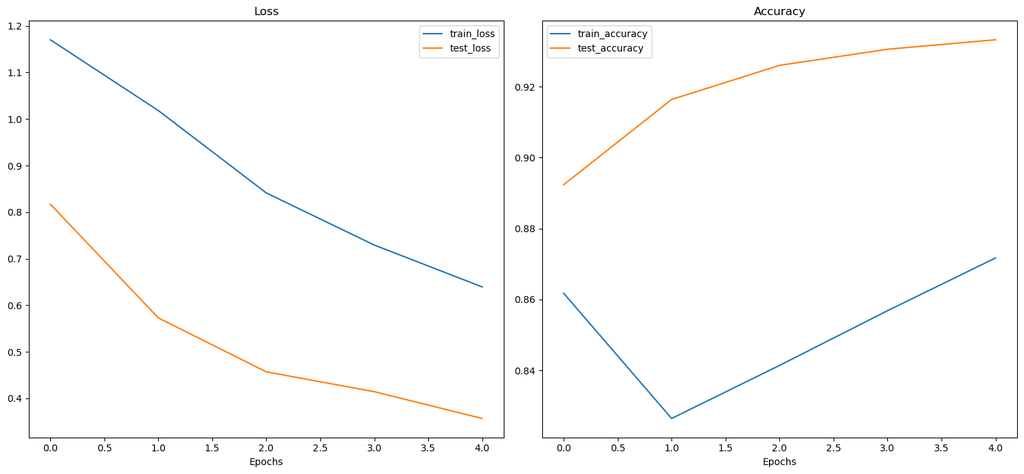

```python
# Plotting the result
plot_loss_curves(results)
```

## Testing your network

It's good practice to test your trained network on test data, images the network has never seen either in training or validation. This will give you a good estimate for the model's performance on completely new images. Run the test images through the network and measure the accuracy, the same way you did validation. You should be able to reach around 70% accuracy on the test set if the model has been trained well.

```python
# Validation on the test set
def validate_model(model: torch.nn.Module,
                  dataloaders: dict,
                  loss_fn: torch.nn.Module,
                  device: torch.device) -> Tuple[float, float]:

    # Make sure model is on the correct device
    model.to(device)

    # Set model to evaluation mode
    model.eval()

    # Initialize metrics
    test_loss = 0
    test_correct = 0
    total_samples = 0

    # Get the test dataset classes
    class_names = dataloaders['test'].dataset.classes

    # Initialize per-class tracking
    class_correct = {i: 0 for i in range(len(class_names))}
    class_total = {i: 0 for i in range(len(class_names))}

    print("\nStarting validation on test set...")

    with torch.no_grad():
        for inputs, labels in dataloaders['test']:
            # Move to device
            inputs, labels = inputs.to(device), labels.to(device)

            # Forward pass
            outputs = model(inputs)

            # Calculate loss
            loss = loss_fn(outputs, labels)
            test_loss += loss.item() * inputs.size(0)  # Multiply by batch size

            # Calculate accuracy
            _, predicted = torch.max(outputs.data, 1)
            total_samples += labels.size(0)
            test_correct += (predicted == labels).sum().item()

            # Per-class accuracy
            for label, pred in zip(labels, predicted):
                label_idx = label.item()
                if label_idx == pred.item():
                    class_correct[label_idx] += 1
                class_total[label_idx] += 1

    # Calculate final metrics
    test_loss = test_loss / len(dataloaders['test'].dataset)  # Average loss per sample
    test_accuracy = (test_correct / total_samples) * 100

    # Print detailed results
    print("\nTest Results:")
    print(f"Test Loss: {test_loss:.3f}")
    print(f"Overall Test Accuracy: {test_accuracy:.2f}%")
    print(f"Total Correct: {test_correct}/{total_samples}")

    # Print per-class accuracy
    print("\nPer-class accuracy:")
    for class_idx, class_name in enumerate(class_names):
        if class_total[class_idx] > 0:
            class_acc = (class_correct[class_idx] / class_total[class_idx]) * 100
            print(f"{class_name}: "
                  f"{class_acc:.2f}% "
                  f"({class_correct[class_idx]}/{class_total[class_idx]})")

    return test_loss, test_accuracy
```

```python
# After training your model
test_loss, test_accuracy = validate_model(model=model,
                                        dataloaders=dataloaders,
                                        loss_fn=loss_fn,
                                        device=device)
```

```
Starting validation on test set...

Test Results:
Test Loss: 0.413
Overall Test Accuracy: 90.23%
Total Correct: 739/819

Per-class accuracy:
1: 100.00% (5/5)
10: 100.00% (3/3)
100: 87.50% (7/8)
101: 100.00% (4/4)
102: 83.33% (5/6)
11: 66.67% (6/9)
12: 88.89% (8/9)
```

[output cut: 95 more lines]

## Save the checkpoint

Now that your network is trained, save the model so you can load it later for making predictions. You probably want to save other things such as the mapping of classes to indices which you get from one of the image datasets: `image_datasets['train'].class_to_idx`. You can attach this to the model as an attribute which makes inference easier later on.

`model.class_to_idx = image_datasets['train'].class_to_idx`

Remember that you'll want to completely rebuild the model later so you can use it for inference. Make sure to include any information you need in the checkpoint. If you want to load the model and keep training, you'll want to save the number of epochs as well as the optimizer state, `optimizer.state_dict`. You'll likely want to use this trained model in the next part of the project, so best to save it now.

```python
def save_checkpoint(model: torch.nn.Module,
                   image_datasets: Dict,
                   optimizer: torch.optim.Optimizer,
                   epochs: int,
                   test_accuracy: float,
                   save_dir: str) -> None:

    # Create save directory if it doesn't exist
    if not os.path.exists(save_dir):
        os.makedirs(save_dir)

    # Attach class_to_idx to model
    model.class_to_idx = image_datasets['train'].class_to_idx

    # Create checkpoint dictionary
    checkpoint = {
        'architecture': 'efficientnet_b0',
        'state_dict': model.state_dict(),
        'class_to_idx': model.class_to_idx,
        'optimizer_state_dict': optimizer.state_dict(),
        'epochs_completed': epochs
    }

    # Save the checkpoint
    checkpoint_path = os.path.join(save_dir, 'efficientnet_b0_checkpoint.pth')
    torch.save(checkpoint, checkpoint_path)


    print(f"\nCheckpoint saved:")
    print(f"Model saved to: {checkpoint_path}")
    print(f"Model accuracy: {test_accuracy:.2f}%")
```

```python
# After training
save_checkpoint(
    model=model,
    image_datasets=image_datasets,
    optimizer=optimizer,
    epochs=NUM_EPOCHS,
    test_accuracy=test_accuracy,
    save_dir='model'
)
```

```
Checkpoint saved:
Model saved to: model/efficientnet_b0_checkpoint.pth
Model accuracy: 90.23%
```

## Loading the checkpoint

At this point it's good to write a function that can load a checkpoint and rebuild the model. That way you can come back to this project and keep working on it without having to retrain the network.

```python
# Function that loads a checkpoint and rebuilds the model
def load_checkpoint(filepath: str, device: torch.device = None) -> torch.nn.Module:
    """
    Load a saved checkpoint and rebuild the EfficientNet model.
    """
    if device is None:
        device = torch.device("cuda" if torch.cuda.is_available() else "cpu")

    # Load checkpoint
    print(f"Loading checkpoint from {filepath}...")
    checkpoint = torch.load(filepath, map_location=device)

    # Initialize model with pretrained weights
    weights = torchvision.models.EfficientNet_B0_Weights.DEFAULT
    model = torchvision.models.efficientnet_b0(weights=weights)


    # Modify the classifier to match your number of classes
    num_classes = len(checkpoint['class_to_idx'])
    model.classifier = nn.Sequential(
        nn.Dropout(p=0.2, inplace=True),
        nn.Linear(1280, num_classes)
    )

    # Load the state dict (this includes classifier)
    model.load_state_dict(checkpoint['state_dict'])

    # Load class_to_idx mapping
    model.class_to_idx = checkpoint['class_to_idx']

    # Move model to device and set to eval mode
    model = model.to(device)

    # Set model to evaluation mode
    model.eval()


    print("Checkpoint loaded successfully!")
    print(f"Architecture: {checkpoint['architecture']}")
    print(f"Number of classes: {num_classes}")
    print(f"Epochs completed: {checkpoint['epochs_completed']}")

    return model
```

```python
# Load the model
device = torch.device("cuda" if torch.cuda.is_available() else "cpu")
model = load_checkpoint('models/efficientnet_b0_checkpoint.pth', device)
```

```
Loading checkpoint from models/efficientnet_b0_checkpoint.pth...
Checkpoint loaded successfully!
Architecture: efficientnet_b0
Number of classes: 102
Epochs completed: 5
```

# Inference for classification

Now you'll write a function to use a trained network for inference. That is, you'll pass an image into the network and predict the class of the flower in the image. Write a function called `predict` that takes an image and a model, then returns the top $K$ most likely classes along with the probabilities. It should look like

```
probs, classes = predict(image_path, model)
print(probs)
print(classes)
> [ 0.01558163  0.01541934  0.01452626  0.01443549  0.01407339]
> ['70', '3', '45', '62', '55']
```

First you'll need to handle processing the input image such that it can be used in your network.

## Image Preprocessing

You'll want to use `PIL` to load the image ([documentation](https://pillow.readthedocs.io/en/latest/reference/Image.html)). It's best to write a function that preprocesses the image so it can be used as input for the model. This function should process the images in the same manner used for training.

First, resize the images where the shortest side is 256 pixels, keeping the aspect ratio. This can be done with the [`thumbnail`](http://pillow.readthedocs.io/en/3.1.x/reference/Image.html#PIL.Image.Image.thumbnail) or [`resize`](http://pillow.readthedocs.io/en/3.1.x/reference/Image.html#PIL.Image.Image.thumbnail) methods. Then you'll need to crop out the center 224x224 portion of the image.

Color channels of images are typically encoded as integers 0-255, but the model expected floats 0-1. You'll need to convert the values. It's easiest with a Numpy array, which you can get from a PIL image like so `np_image = np.array(pil_image)`.

As before, the network expects the images to be normalized in a specific way. For the means, it's `[0.485, 0.456, 0.406]` and for the standard deviations `[0.229, 0.224, 0.225]`. You'll want to subtract the means from each color channel, then divide by the standard deviation.

And finally, PyTorch expects the color channel to be the first dimension but it's the third dimension in the PIL image and Numpy array. You can reorder dimensions using [`ndarray.transpose`](https://docs.scipy.org/doc/numpy-1.13.0/reference/generated/numpy.ndarray.transpose.html). The color channel needs to be first and retain the order of the other two dimensions.

```python
def process_image(image_path):
    ''' Scales, crops, and normalizes a PIL image for a PyTorch model,
        returns an Numpy array
    '''
    # Load image
    img = Image.open(image_path)

    # Resize with shortest side 256
    if img.size[0] < img.size[1]:
        ratio = 256.0 / img.size[0]
        new_size = (256, int(img.size[1] * ratio))
    else:
        ratio = 256.0 / img.size[1]
        new_size = (int(img.size[0] * ratio), 256)

    img.thumbnail(new_size)

    # Center crop to 224x224
    width, height = img.size
    left = (width - 224) / 2
    top = (height - 224) / 2
    right = left + 224
    bottom = top + 224

    img = img.crop((left, top, right, bottom))

    # Convert to numpy array and normalize
    np_image = np.array(img) / 255
    mean = np.array([0.485, 0.456, 0.406])
    std = np.array([0.229, 0.224, 0.225])
    np_image = (np_image - mean) / std

    # Transpose for PyTorch (color channel first)
    np_image = np_image.transpose((2, 0, 1))

    return np_image
```

To check your work, the function below converts a PyTorch tensor and displays it in the notebook. If your `process_image` function works, running the output through this function should return the original image (except for the cropped out portions).

```python
def imshow(image, ax=None, title=None):
    """Imshow for Tensor."""
    if ax is None:
        fig, ax = plt.subplots()

    # PyTorch tensors assume the color channel is the first dimension
    # but matplotlib assumes is the third dimension
    image = image.numpy().transpose((1, 2, 0))

    # Undo preprocessing
    mean = np.array([0.485, 0.456, 0.406])
    std = np.array([0.229, 0.224, 0.225])
    image = std * image + mean

    # Image needs to be clipped between 0 and 1 or it looks like noise when displayed
    image = np.clip(image, 0, 1)

    ax.imshow(image)

    return ax
```

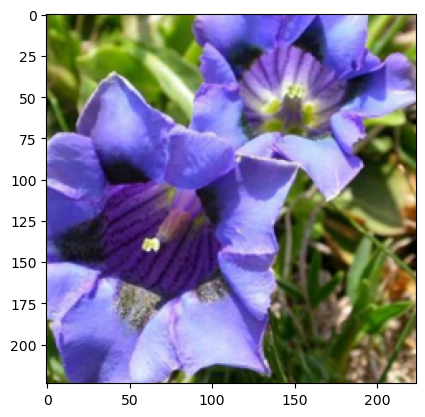

```python
# Test the precess image function with imshow to process an image
image_path = './flowers/test/28/image_05230.jpg'

imshow(torch.from_numpy(process_image(image_path)))
```

## Class Prediction

Once you can get images in the correct format, it's time to write a function for making predictions with your model. A common practice is to predict the top 5 or so (usually called top-$K$) most probable classes. You'll want to calculate the class probabilities then find the $K$ largest values.

To get the top $K$ largest values in a tensor use [`x.topk(k)`](http://pytorch.org/docs/master/torch.html#torch.topk). This method returns both the highest `k` probabilities and the indices of those probabilities corresponding to the classes. You need to convert from these indices to the actual class labels using `class_to_idx` which hopefully you added to the model or from an `ImageFolder` you used to load the data (see here). Make sure to invert the dictionary so you get a mapping from index to class as well.

Again, this method should take a path to an image and a model checkpoint, then return the probabilities and classes.

```
probs, classes = predict(image_path, model)
print(probs)
print(classes)
> [ 0.01558163  0.01541934  0.01452626  0.01443549  0.01407339]
> ['70', '3', '45', '62', '55']
```

```python
def predict(image_path: str, model: torch.nn.Module):
    """
    Predict the class of an image using a trained deep learning model.

    Args:
        image_path: Path to image file
        model: Trained model
        cat_to_name: Dictionary mapping categories to real names
        device: Device to run prediction on
        topk: Number of top predictions to return

    Returns:
        Tuple of (probabilities, class indices, class names)
    """

    device = torch.device("cuda" if torch.cuda.is_available() else "cpu")

    # Move model to evaluation mode
    model.eval()

    model.to(device)

    # Process image
    np_image = process_image(image_path)
    image_tensor = torch.from_numpy(np_image).float().unsqueeze(0).to(device)

    # Get predictions
    with torch.no_grad():
        output = model(image_tensor)

        # Apply softmax to get probabilities
        probabilities = torch.nn.functional.softmax(output, dim=1)

        # Get top k probabilities and indices
        topk = 5
        top_probs, top_indices = probabilities.topk(topk)
        top_probs = top_probs.squeeze().cpu().numpy().tolist()
        np.set_printoptions(precision=8, suppress=True)
        top_indices = top_indices.squeeze().cpu().numpy().tolist()

        # Convert indices to classes

        # Map indices to class labels
        idx_to_class = {val: key for key, val in model.class_to_idx.items()}
        top_classes = [idx_to_class[idx] for idx in top_indices]

    return top_probs, top_classes
```

```python
# Load the category names
with open('cat_to_name.json', 'r') as f:
    cat_to_name = json.load(f)
```

```python
# Get predictions
probs, classes = predict(image_path=image_path, model=model)
```

```python
print(np.array(probs))
print(classes)

# Print results with flower names
print("\nTop five predictions:")
for i, (prob, cls) in enumerate(zip(probs, classes), 1):
    flower_name = cat_to_name[cls]
    print(f"{i}. {flower_name}: {prob:.4f}")
```

```
[0.93866533 0.04068233 0.00663905 0.00237277 0.00224353]
['28', '9', '19', '3', '76']

Top five predictions:
1. stemless gentian: 0.9387
2. monkshood: 0.0407
3. balloon flower: 0.0066
4. canterbury bells: 0.0024
5. morning glory: 0.0022
```

## Sanity Checking

Now that you can use a trained model for predictions, check to make sure it makes sense. Even if the testing accuracy is high, it's always good to check that there aren't obvious bugs. Use `matplotlib` to plot the probabilities for the top 5 classes as a bar graph, along with the input image. It should look like this:

[figure not shown]

You can convert from the class integer encoding to actual flower names with the `cat_to_name.json` file (should have been loaded earlier in the notebook). To show a PyTorch tensor as an image, use the `imshow` function defined above.

```python
def plot_predictions(image_path, probs, classes, cat_to_name):
    """
    Display an image along with the top 5 classes.

    Args:
        image_path: Path to image file
        probs: List of prediction probabilities
        classes: List of predicted class indices
        cat_to_name: Dictionary mapping class indices to flower names
    """
    # Convert class indices to flower names
    flower_names = [cat_to_name[cls] for cls in classes]

    # Process image for display
    processed_image = process_image(image_path)

    # Create figure with two subplots
    fig, (ax1, ax2) = plt.subplots(figsize=(6,10), ncols=1, nrows=2)

    # Display the image
    imshow(torch.from_numpy(processed_image), ax=ax1)
    ax1.set_title(f'Predicted: {flower_names[0]}',
                  fontsize=15,
                  pad=15)
    ax1.axis('off')

    # Create bar chart of predictions
    y_pos = np.arange(len(flower_names))
    ax2.barh(y_pos, probs)
    ax2.set_yticks(y_pos)
    ax2.set_yticklabels(flower_names)
    ax2.invert_yaxis()  # Highest probability at top
    ax2.set_xlabel('Probability')
    ax2.set_title('Top 5 Predictions')

    plt.tight_layout()
    plt.show()
```

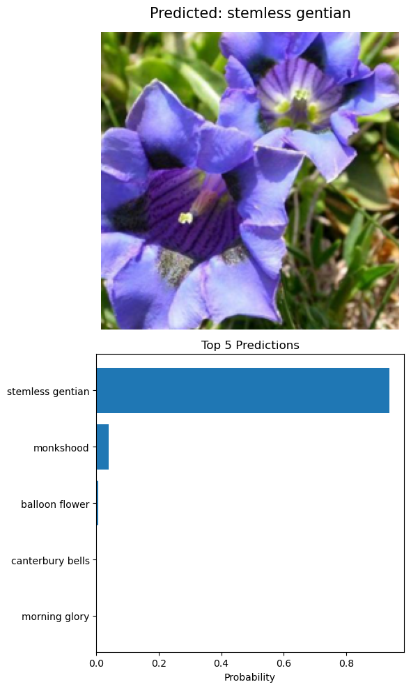

```python
# Display predictions
plot_predictions(image_path, probs, classes, cat_to_name)
```

As we can see here, the model only trained with 5 epochs arrived to correctly predict the name of the flower with precise and higher probability